# Tidytext

### Using Histogram on the Newspaper

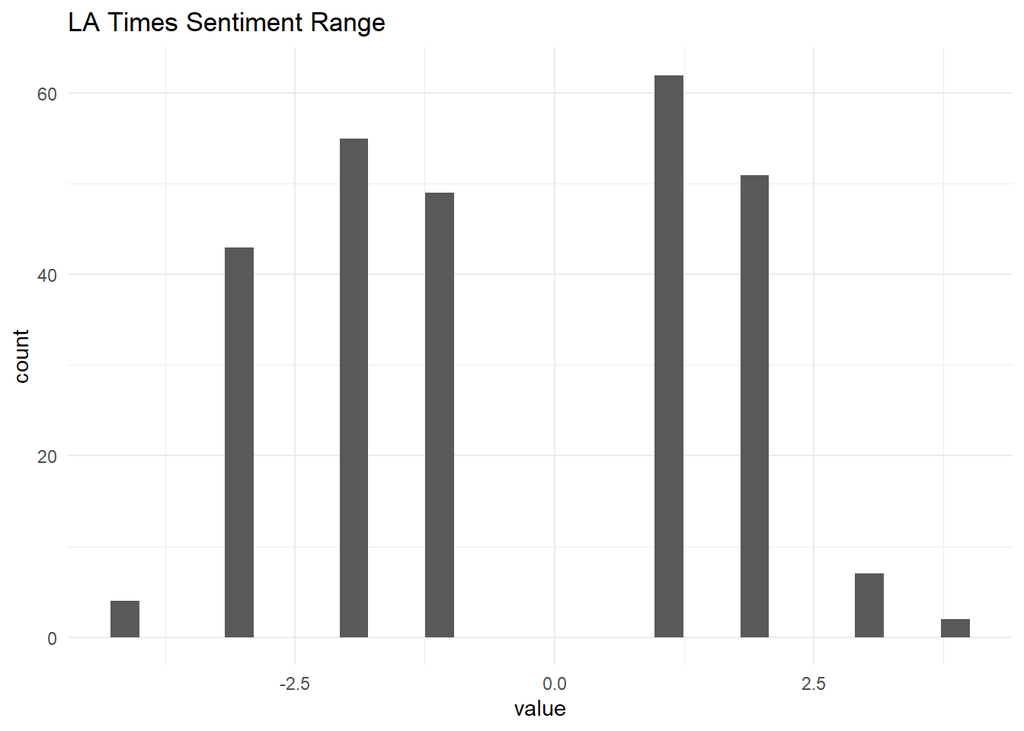

It can be concluded that the histogram agrees with the nrc and bing sentiment analysis. This can be seen by the high negativity, higher word count below 0, and low positivity, lower word count above 0. Therefore, the words are more skewed to the left, indicating that the western region articles tend to be more negative.

### Using Word Cloud on the Newspaper

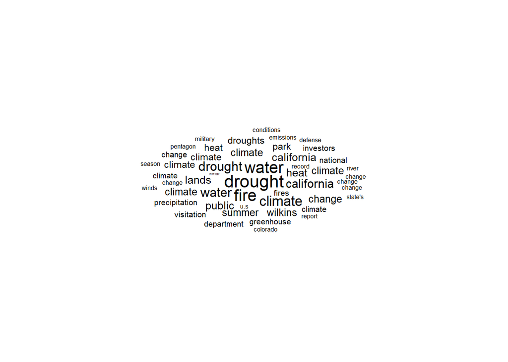

Based on the output of the word cloud that corresponds to the LA Times newspaper, which in this case is the corpus formed by combining the articles (documents), the most commonly said words are those that appear bolder, larger, an more often. Therefore, it seems that words such as “drought”, “water”,“fire”, and “climate” are mentioned quite often in Los Angeles Times Newspaper articles about climate change. This completely makes sense because in the western region, especially California, they often suffer from droughts, and wild fires. One of the most surprising words for me was “change” as I thought this word would possibly appear bolder and larger, because it would make sense that this word would be used often in articles about climate CHANGE.